# Jogos Olímpicos de Verão:soluções

fnaufel

06/12/2021 (v. 10/01/2022)

**AVISO**

- Os dados usados para esta lista foram baseados em https://www.kaggle.com/heesoo37/120-years-of-olympic-history-athletes-and-results
- Estes, por sua vez, foram raspados de http://www.sports-reference.com/, usando o código R em https://github.com/rgriff23/Olympic_history/blob/master/R/olympics%20scrape.R e em https://github.com/rgriff23/Olympic_history/blob/master/R/olympics%20wrangle.R
- Quando você for calcular totais de medalhas por país, vai chegar a valores maiores do que os verdadeiros. Por exemplo, [de acordo com a wikipédia](https://pt.wikipedia.org/wiki/Lista_de_medalhas_brasileiras_nos_Jogos_Ol%C3%ADmpicos), o Brasil nunca ganhou mais que $21$ medalhas (de qualquer tipo) em uma olimpíada.
- O motivo para isto é que este conjunto de dados tem como unidades os atletas. Em esportes coletivos, como futebol, um país ganhar uma medalha é registrado neste *data frame* como cada atleta da equipe ganhando uma medalha.
- Conclusão: nos resultados, os totais de medalhas contam uma medalha para cada atleta da equipe que ganhou medalha. Os dados não estão errados; só estão estruturados de um jeito que não é o normal para contar totais de medalhas dos países.

**INSTRUÇÕES**

- Fique à vontade para consultar os coleguinhas, mas não copie as respostas deles. Se eu achar que você copiou, vamos ter uma entrevista síncrona, por vídeo, com horas de duração, para que eu tenha certeza de que você sabe o que fez.
- Entregue (via Moodle) este arquivo .Rmd com suas respostas. Não esqueça de colocar o seu nome no campo `author`, no início do arquivo.
- Além do arquivo .Rmd, entregue também (via Moodle) um arquivo contendo um vídeo de no máximo 5 minutos onde você explica em detalhes a resolução de uma das suas questões.
- Todos os gráficos devem ser feitos com o pacote `ggplot2`.
- Todos os gráficos devem incluir títulos, rótulos, legendas (quando necessárias), e outros elementos para facilitar a compreensão. Imagine que seus gráficos serão publicados em uma revista.
- Trate o texto e o código com o mesmo cuidado. Use parágrafos no texto e indentação e quebras de linha no código. A legibilidade do texto e do código também fazem parte da apresentação.
- Bom trabalho.

# 1 Sumário

Nesta atividade, você vai trabalhar com o conjunto de dados `atletas`.

1. Entre `?atletas` para ver a documentação.
2. Use `glimpse(atletas)` para ver a estrutura da *tibble*.
3. Use a função `dfSummary`, do pacote `summaryTools`, para ver um sumário mais detalhado da *tibble*.

   ```r
   atletas %>% dfSummary() %>% print(method = 'render')
   ```

   | **Variável** | **Estatísticas / Valores** | **Freqs (% de Válidos)** | **Grafo** | **Faltante** |
   | --- | --- | --- | --- | --- |
   | id [numeric] | Média (dp) : 68046,7 (39166,6) mín < mediana < máx: 1 < 68436 < 135568 IQE (CV) : 67796 (0,6) | 97456 valores distintos |  | 0 (0,0%) |
   | nome [character] | 1. Joseph "Josy" Stoffel 2. Takashi Ono 3. Andreas Wecker 4. Johann "Hans" Sauter 5. Michel Mathiot 6. Karl Tore William Thoress 7. Michael Fred Phelps, II 8. Yordan Yovchev Yovchev 9. Oksana Aleksand… | 38 ( 0,0% ) 33 ( 0,0% ) 32 ( 0,0% ) 31 ( 0,0% ) 31 ( 0,0% ) 30 ( 0,0% ) 30 ( 0,0% ) 30 ( 0,0% ) 29 ( 0,0% ) 26 ( 0,0% ) 185759 ( 99,8% ) |  | 0 (0,0%) |
   | sexo [character] | 1. F 2. M | 57652 ( 31,0% ) 128417 ( 69,0% ) |  | 0 (0,0%) |
   | idade [numeric] | Média (dp) : 25,2 (5,9) mín < mediana < máx: 11 < 24 < 84 IQE (CV) : 7 (0,2) | 67 valores distintos |  | 3102 (1,7%) |
   | altura [numeric] | Média (dp) : 175,5 (11) mín < mediana < máx: 127 < 175 < 226 IQE (CV) : 15 (0,1) | 95 valores distintos |  | 21780 (11,7%) |
   | peso [numeric] | Média (dp) : 70,6 (14,9) mín < mediana < máx: 25 < 70 < 214 IQE (CV) : 19 (0,2) | 219 valores distintos |  | 22124 (11,9%) |
   | pais [character] | 1. USA 2. GBR 3. AUS 4. FRA 5. ITA 6. CAN 7. JPN 8. GER 9. HUN 10. URS [ 215 outros ] | 10541 ( 5,7% ) 7647 ( 4,1% ) 6888 ( 3,7% ) 6837 ( 3,7% ) 6483 ( 3,5% ) 5941 ( 3,2% ) 5685 ( 3,1% ) 5571 ( 3,0% ) 4843 ( 2,6% ) 4622 ( 2,5% ) 121011 ( 65,0% ) |  | 0 (0,0%) |
   | ano [numeric] | Média (dp) : 1987,2 (20,1) mín < mediana < máx: 1948 < 1992 < 2016 IQE (CV) : 32 (0) | 18 valores distintos |  | 0 (0,0%) |
   | cidade [character] | 1. London 2. Sydney 3. Atlanta 4. Rio de Janeiro 5. Beijing 6. Athina 7. Barcelona 8. Seoul 9. Munich 10. Los Angeles [ 8 outros ] | 19325 ( 10,4% ) 13821 ( 7,4% ) 13780 ( 7,4% ) 13688 ( 7,4% ) 13602 ( 7,3% ) 13443 ( 7,2% ) 12977 ( 7,0% ) 12037 ( 6,5% ) 10304 ( 5,5% ) 9454 ( 5,1% ) 53638 ( 28,8% ) |  | 0 (0,0%) |
   | esporte [character] | 1. Athletics 2. Gymnastics 3. Swimming 4. Cycling 5. Rowing 6. Shooting 7. Fencing 8. Canoeing 9. Wrestling 10. Sailing [ 27 outros ] | 31500 ( 16,9% ) 22543 ( 12,1% ) 21244 ( 11,4% ) 8918 ( 4,8% ) 8831 ( 4,7% ) 8052 ( 4,3% ) 7643 ( 4,1% ) 6028 ( 3,2% ) 5885 ( 3,2% ) 5606 ( 3,0% ) 59819 ( 32,1% ) |  | 0 (0,0%) |
   | evento [character] | 1. Football Men's Football 2. Hockey Men's Hockey 3. Basketball Men's Basketba 4. Water Polo Men's Water Po 5. Cycling Men's Road Race, 6. Handball Men's Handball 7. Volleyball Men's Volleyba 8. Gymna… | 4493 ( 2,4% ) 3495 ( 1,9% ) 3081 ( 1,7% ) 2714 ( 1,5% ) 2467 ( 1,3% ) 2159 ( 1,2% ) 1861 ( 1,0% ) 1764 ( 0,9% ) 1749 ( 0,9% ) 1746 ( 0,9% ) 160540 ( 86,3% ) |  | 0 (0,0%) |
   | medalha [character] | 1. Bronze 2. Gold 3. Silver | 8955 ( 34,2% ) 8690 ( 33,2% ) 8542 ( 32,6% ) |  | 159882 (85,9%) |

   Gerado por summarytools 1.0.0 ([R](https://www.r-project.org/) versão 4.1.2)  
   2022-01-10

# 2 Idades e esportes

Nesta seção, você vai explorar os dados, mas sem gerar gráficos.

1. Qual a idade dos atletas mais jovens? Quem são? De onde são? Em que ano competiram? Em que esportes? Ganharam medalha? Use a função `slice_min`.

   ```r
   atletas %>%
     slice_min(idade) %>%
     select(id, nome, idade, pais, ano, esporte, medalha) %>%
     arrange(ano)
   ```

   | id | nome | idade | pais | ano | esporte | medalha |
   | --- | --- | --- | --- | --- | --- | --- |
   | 126307 | Liana Vicens | 11 | PUR | 1968 | Swimming | NA |
   | 126307 | Liana Vicens | 11 | PUR | 1968 | Swimming | NA |
   | 126307 | Liana Vicens | 11 | PUR | 1968 | Swimming | NA |
   | 126307 | Liana Vicens | 11 | PUR | 1968 | Swimming | NA |
   | 37333 | Carlos Bienvenido Front Barrera | 11 | ESP | 1992 | Rowing | NA |

2. Qual a idade dos atletas mais velhos? Quem são? De onde são? Em que ano competiram? Em que esportes? Ganharam medalha? Use a função `slice_max`.

   ```r
   atletas %>%
     slice_max(idade) %>%
     select(id, nome, idade, pais, ano, esporte, medalha) %>%
     arrange(ano)
   ```

   | id | nome | idade | pais | ano | esporte | medalha |
   | --- | --- | --- | --- | --- | --- | --- |
   | 5146 | George Denholm Armour | 84 | GBR | 1948 | Art Competitions | NA |

3. Aposto que você não sabia que havia competição de artes nas Olimpíadas! Até que ano isto aconteceu?

   ```r
   atletas %>%
     filter(esporte == 'Art Competitions') %>%
     pull(ano) %>%
     max()
   ```

   ```
   ## [1] 1948
   ```

4. Quais eram os eventos das competições de artes? Use a função `distinct`.

   ```r
   atletas %>%
     filter(esporte == 'Art Competitions') %>%
     distinct(evento) %>%
     arrange(evento)
   ```

   | evento |
   | --- |
   | Art Competitions Mixed Architecture, Architectural Designs |
   | Art Competitions Mixed Architecture, Designs For Town Planning |
   | Art Competitions Mixed Architecture, Unknown Event |
   | Art Competitions Mixed Literature, Dramatic Works |
   | Art Competitions Mixed Literature, Epic Works |
   | Art Competitions Mixed Literature, Lyric Works |
   | Art Competitions Mixed Literature, Unknown Event |
   | Art Competitions Mixed Music, Compositions For Orchestra |
   | Art Competitions Mixed Music, Instrumental And Chamber |
   | Art Competitions Mixed Music, Vocals |

   [output cut: 8 more lines]

5. Elimine do *data frame* as linhas relativas a artes.

   ```r
   atletas <-
     atletas %>%
       filter(esporte != 'Art Competitions')
   ```

6. Quais as idades mínima e máxima agora?

   ```r
   atletas %>%
     pull(idade) %>%
     summary()
   ```

   ```
   ##    Min. 1st Qu.  Median    Mean 3rd Qu.    Max.    NA's
   ##   11,00   21,00   24,00   25,13   28,00   71,00    3025
   ```

7. Quais os dados dos atletas que têm a idade máxima?

   ```r
   atletas %>%
     slice_max(idade) %>%
     select(id, nome, idade, pais, ano, esporte, medalha) %>%
     arrange(ano)
   ```

   | id | nome | idade | pais | ano | esporte | medalha |
   | --- | --- | --- | --- | --- | --- | --- |
   | 49287 | Hiroshi Hoketsu | 71 | JPN | 2012 | Equestrianism | NA |

8. Quais os atletas mais jovens a ganhar medalha? De onde são? Em que anos ganharam? Em que esportes? Quais medalhas?

   ```r
   atletas %>%
     filter(!is.na(medalha)) %>%
     slice_min(idade) %>%
     select(nome, idade, pais, ano, esporte, medalha)
   ```

   | nome | idade | pais | ano | esporte | medalha |
   | --- | --- | --- | --- | --- | --- |
   | Robin Marie Corsiglia (-Scholefield) | 13 | CAN | 1976 | Swimming | Bronze |
   | Donna Elizabeth de Varona (-Pinto) | 13 | USA | 1960 | Swimming | Gold |
   | Kornelia Ender (-Matthes, -Grummt) | 13 | GDR | 1972 | Swimming | Silver |
   | Kornelia Ender (-Matthes, -Grummt) | 13 | GDR | 1972 | Swimming | Silver |
   | Kornelia Ender (-Matthes, -Grummt) | 13 | GDR | 1972 | Swimming | Silver |
   | Fu Mingxia | 13 | CHN | 1992 | Diving | Gold |
   | Gina Elena Gogean (-Groza) | 13 | ROU | 1992 | Gymnastics | Silver |
   | Nian Yun | 13 | CHN | 1996 | Swimming | Silver |
   | Klaus Zerta | 13 | GER | 1960 | Rowing | Gold |

9. Quais os atletas mais velhos a ganhar medalha? De onde são? Em que anos ganharam? Em que esportes? Quais medalhas?

   ```r
   atletas %>%
     filter(!is.na(medalha)) %>%
     slice_max(idade) %>%
     select(nome, idade, pais, ano, esporte, medalha)
   ```

   | nome | idade | pais | ano | esporte | medalha |
   | --- | --- | --- | --- | --- | --- |
   | Louis Noverraz | 66 | SUI | 1968 | Sailing | Silver |

# 3 *Scatterplots*

1. Usando `group_by` e `summarize`, crie o *data frame* `medalhas_atletas` com as colunas `pais`, `ano`, `atletas` (total de participações do país naquele ano) e `medalhas` (total de medalhas do país naquele ano). Descarte os registros onde o número de medalhas é menor que $50$.

   ```r
   medalhas_atletas <- atletas %>%
     group_by(pais, ano) %>%
     summarize(
       atletas = n_distinct(id),
       medalhas = sum(!is.na(medalha)),
       .groups = 'drop'
     ) %>%
     filter(medalhas >= 50) %>%
     arrange(pais)

   medalhas_atletas
   ```

   | pais | ano | atletas | medalhas |
   | --- | --- | --- | --- |
   | ARG | 2008 | 132 | 51 |
   | AUS | 1956 | 298 | 67 |
   | AUS | 1968 | 128 | 51 |
   | AUS | 1984 | 242 | 52 |
   | AUS | 1992 | 279 | 57 |
   | AUS | 1996 | 417 | 132 |
   | AUS | 2000 | 617 | 183 |
   | AUS | 2004 | 470 | 157 |
   | AUS | 2008 | 432 | 149 |
   | AUS | 2012 | 405 | 114 |

   [output cut: 151 more lines]

2. Gere um *scatterplot* de número de medalhas por número de participações. Use `geom_smooth` para traçar uma reta de regressão. Comente o resultado.

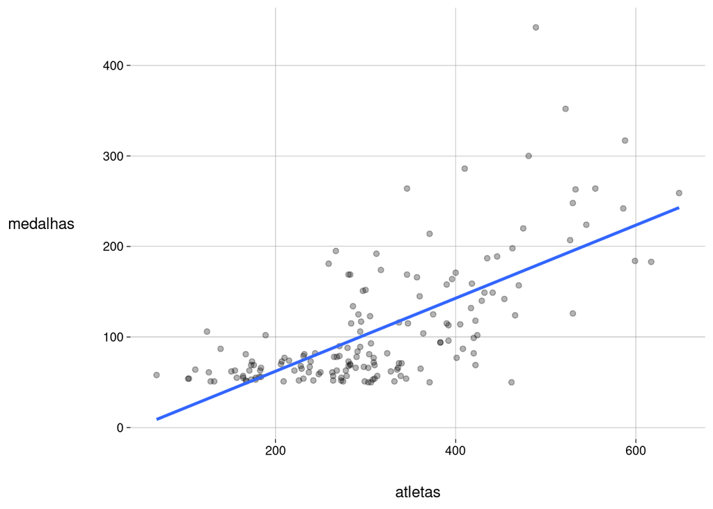

   ```r
   sp_medalha_atletas <- medalhas_atletas %>%
     ggplot(aes(atletas, medalhas)) +
       geom_point(alpha = .3) +
       geom_smooth(se = FALSE, method = 'lm')

   sp_medalha_atletas
   ```

3. Facete o *scatterplot* anterior por ano. Disponha os subgráficos em $3$ linhas e $6$ colunas.

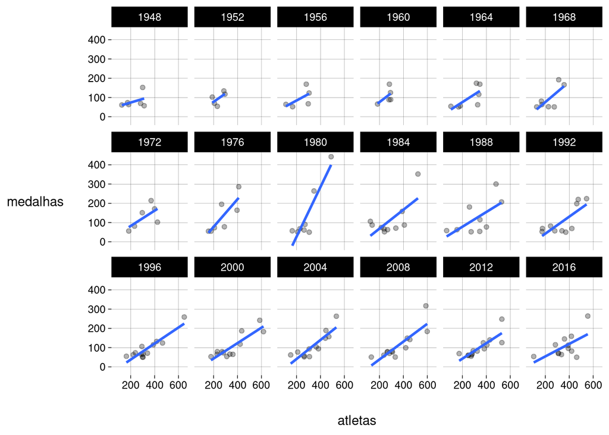

   ```r
   sp_medalha_atletas +
     facet_wrap(~ano, nrow = 3)
   ```

4. Como você interpreta as diferentes quantidades de pontos em cada subgráfico?
   - Ao longo dos anos, a quantidade de países que ganharam $50$ ou mais medalhas aumentou.
   - Ao longo dos anos, a quantidade de participações de alguns países aumentou.
   - Ao longo dos anos, a variação da quantidade de participações aumentou. Em $1948$, o gráfico mostra entre $100$ e $300$ participações. Em $2016$, foram entre $100$ e $600$ participações, aproximadamente.
5. Houve uma única vez em que um país ganhou mais de $400$ medalhas em um ano. Descubra o que aconteceu para facilitar essa ocorrência.

   Em $1980$, os [jogos foram realizados em Moscou, na União Soviética](https://pt.wikipedia.org/wiki/Jogos_Ol%C3%ADmpicos_de_Ver%C3%A3o_de_1980), e os Estados Unidos comandaram um boicote aos jogos por motivos políticos, fazendo com que $69$ países deixassem de enviar atletas.

   Em $1984$, foi a vez de a União Soviética e outros países comunistas [boicotarem os jogos de Los Angeles](https://pt.wikipedia.org/wiki/Jogos_Ol%C3%ADmpicos_de_Ver%C3%A3o_de_1984#Boicote), mas o gráfico de $1984$ mostra que os efeitos não foram tão drásticos quanto os do boicote de $1980$.
6. Considere agora apenas os registros onde `medalhas` é maior que $200$. Faça um *scatterplot* de número de medalhas por número de participações, onde cada ponto é colorido de acordo com o país. Aumente o tamanho de todos os pontos para facilitar a leitura. Não gere a reta de regressão. Comente o resultado.

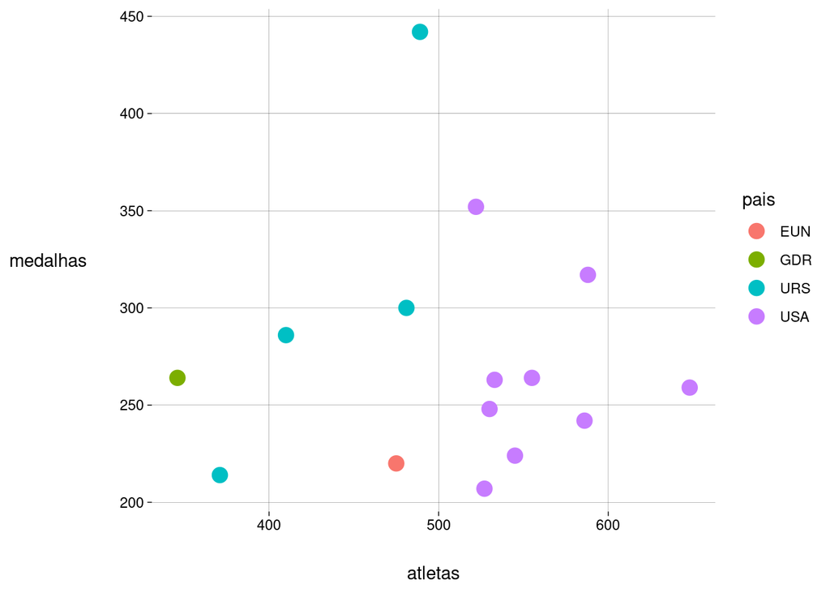

   ```r
   medalhas_atletas %>%
     filter(medalhas > 200) %>%
     ggplot(aes(atletas, medalhas, color = pais)) +
       geom_point(size = 4)
   ```

   Considerando apenas os países e os anos onde o país ganhou mais de $200$ medalhas:
   - Apenas os Estados Unidos tiveram mais de $500$ participações, com quantidade de medalhas entre $200$ e $350$, aproximadamente.
   - A União Soviética teve entre $350$ e $500$ participações, mas, com exceção das quase $450$ medalhas em Moscou $1980$, chegou no máximo a $300$ medalhas.
   - Rússia (EUN) e Alemanha Oriental (GDR) aparecem com números pouco expressivos em comparação com Estados Unidos e União Soviética.

# 4 Histogramas

1. Usando o *data frame* `atletas` (sem as artes), gere um histograma das idades de todos os atletas, com classes de $5$ anos de largura.

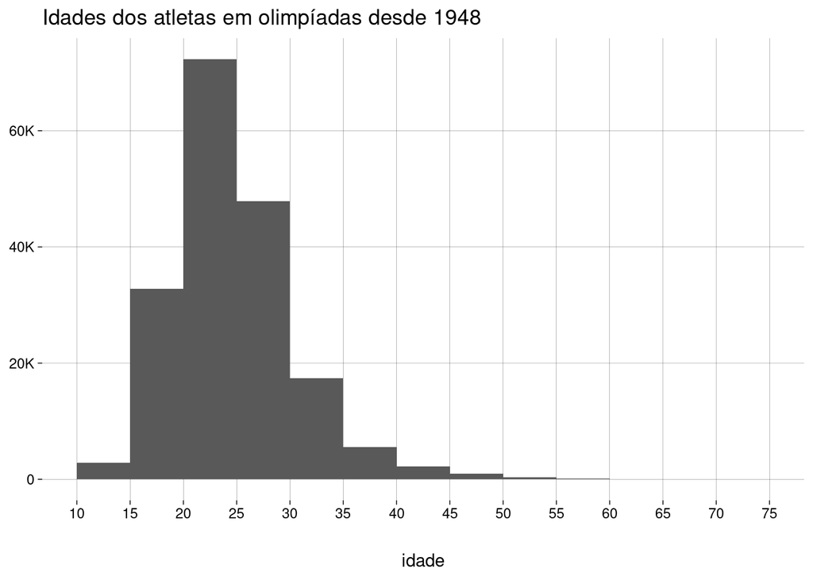

   ```r
   breaks <- seq(10, 75, 5)

   hist_idades <- atletas %>%
     ggplot(aes(idade)) +
       geom_histogram(breaks = breaks) +
       scale_x_continuous(breaks = breaks) +
       scale_y_continuous(labels = label_number_si()) +
       labs(
         y = NULL,
         title = paste(
           'Idades dos atletas em olimpíadas desde',
           ano_inicial
         )
       )

   hist_idades
   ```

2. Faça a mesma coisa, mas apenas para idades maiores ou iguais a $55$ anos.

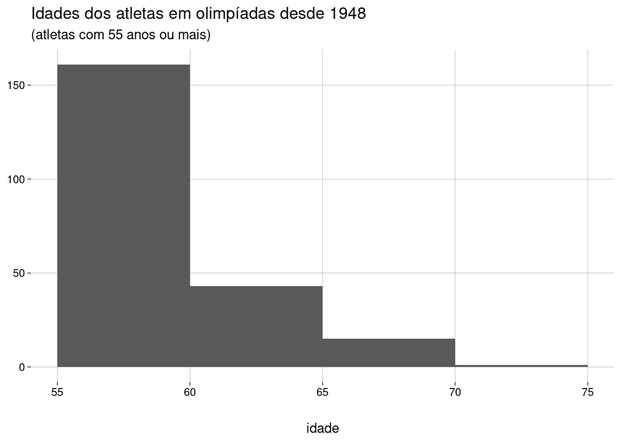

   ```r
   breaks <- seq(55, 75, 5)

   hist_idades_velhos <- atletas %>%
     filter(idade >= 55) %>%
     ggplot(aes(idade)) +
       geom_histogram(breaks = breaks) +
       scale_x_continuous(breaks = breaks) +
       scale_y_continuous(labels = label_number_si()) +
       labs(
         y = NULL,
         title = paste('Idades dos atletas em olimpíadas desde', ano_inicial),
         subtitle = '(atletas com 55 anos ou mais)'
       )

   hist_idades_velhos
   ```

3. Gere dois histogramas de todas as idades, por sexo, com classes de $5$ anos de largura. Use `facet_wrap`.

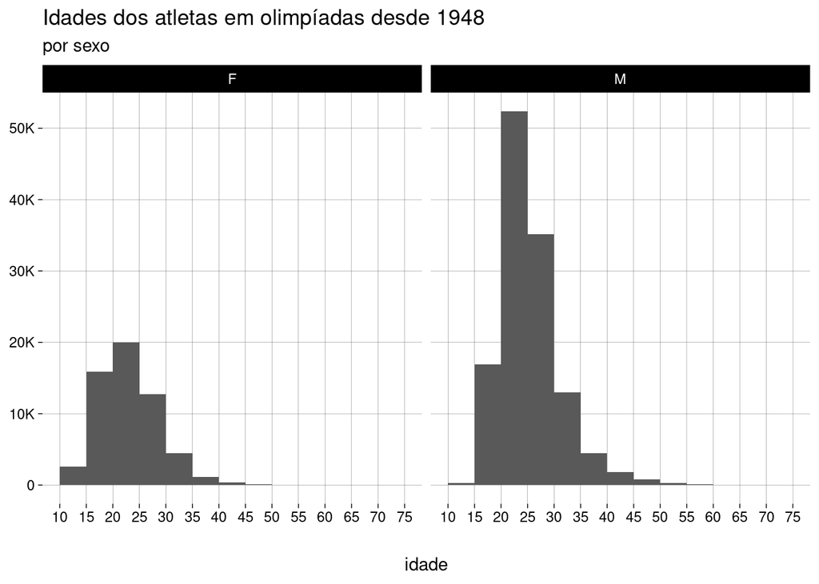

   ```r
   hist_idades +
     labs(subtitle = 'por sexo') +
     facet_wrap(~sexo)
   ```

4. Comente o resultado, sobretudo nas idades abaixo de $20$ anos. Por que você acha que acontece isso? Analise os dados como você achar mais adequado para confirmar ou refutar sua hipótese.
   - Há muito mais homens que mulheres, no total e na maioria das faixas etárias.
   - Uma faixa etária onde há muito mais mulheres do que homens é a de $10$ a $15$ anos.
   - Mais abaixo, você vai constatar que isso é por causa da ginástica rítmica, onde competem apenas mulheres, grande parte delas muito jovens.
5. Quais são os esportes com a menor idade média e a maior idade média? Use `group_by` e `summarize`. Ignore os valores `NA` na hora de computar a média (veja a ajuda da função `mean`).

   ```r
   extremos <- atletas %>%
     group_by(esporte) %>%
     summarize(media = mean(idade, na.rm = TRUE)) %>%
     arrange(media) %>%
     slice(c(1, n()))

   extremos
   ```

   | esporte | media |
   | --- | --- |
   | Rhythmic Gymnastics | 18,73708 |
   | Equestrianism | 34,34295 |

6. Quais são os esportes com a menor idade mediana e a maior idade mediana? Use `group_by` e `summarize`. Ignore os valores `NA` na hora de computar a mediana (veja a ajuda da função `median`).

   ```r
   atletas %>%
     group_by(esporte) %>%
     summarize(mediana = median(idade, na.rm = TRUE)) %>%
     arrange(mediana) %>%
     slice(c(1, n()))
   ```

   | esporte | mediana |
   | --- | --- |
   | Rhythmic Gymnastics | 18 |
   | Equestrianism | 33 |

7. Usando somente os atletas dos esportes com menor idade média e maior idade média (achados acima), gere dois histogramas das idades, por esporte, com classes de $5$ anos. Use `facet_wrap`.

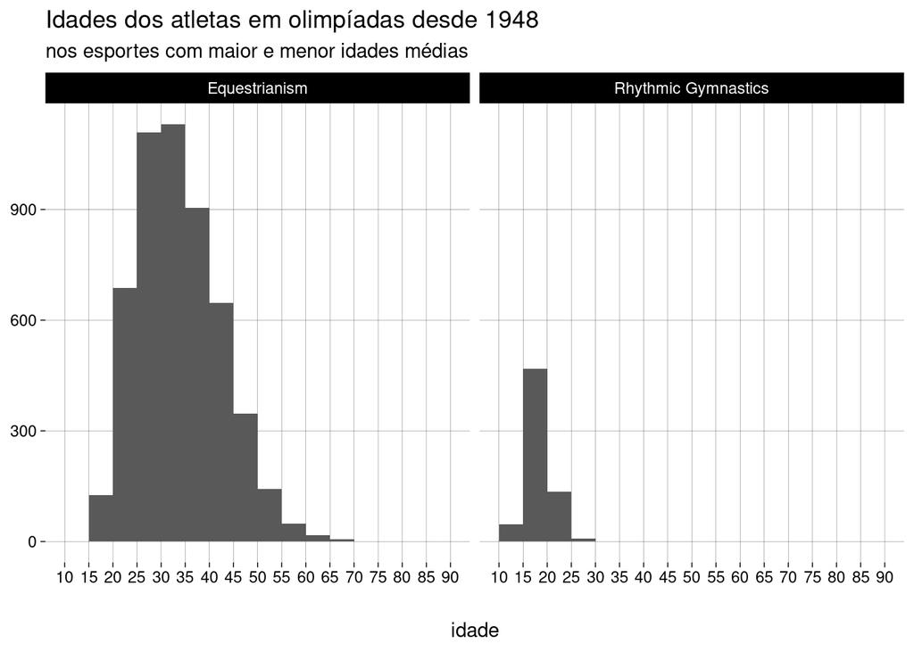

   ```r
   breaks <- seq(10, 90, 5)
   esportes <- extremos %>% pull(esporte)

   atletas %>%
     filter(esporte %in% esportes) %>%
     ggplot(aes(idade)) +
       geom_histogram(breaks = breaks) +
       scale_x_continuous(breaks = breaks) +
       scale_y_continuous(labels = label_number_si()) +
       labs(
         y = NULL,
         title = paste('Idades dos atletas em olimpíadas desde', ano_inicial),
         subtitle = 'nos esportes com maior e menor idades médias'
       ) +
       facet_wrap(~esporte)
   ```

8. Repita o item anterior, desta vez usando `facet_grid` em vez de `facet_wrap`, para gerar $4$ histogramas, cada um com um esporte e um sexo. Comente o resultado.

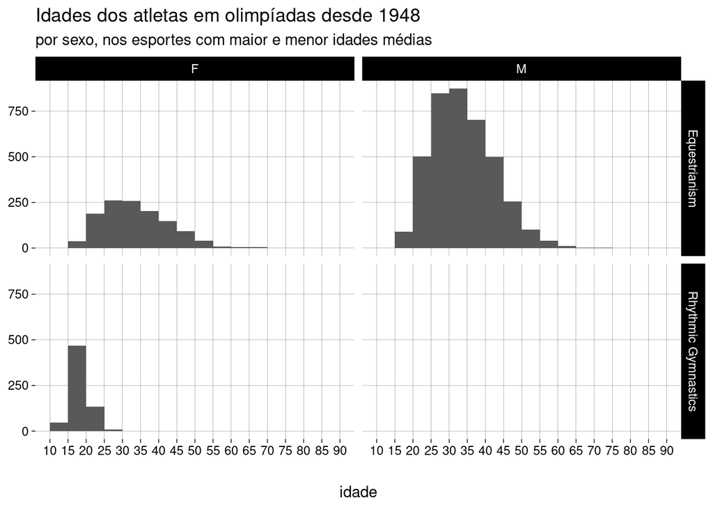

   ```r
   breaks <- seq(10, 90, 5)
   esportes <- extremos %>% pull(esporte)

   atletas %>%
     filter(esporte %in% esportes) %>%
     ggplot(aes(idade)) +
       geom_histogram(breaks = breaks) +
       scale_x_continuous(breaks = breaks) +
       scale_y_continuous(labels = label_number_si()) +
       labs(
         y = NULL,
         title = paste('Idades dos atletas em olimpíadas desde', ano_inicial),
         subtitle = 'por sexo, nos esportes com maior e menor idades médias'
       ) +
       facet_grid(cols = vars(sexo), rows = vars(esporte))
   ```

# 5 *Boxplots*

1. Gere *boxplots* lado a lado, um *boxplot* por ano, para as alturas de todos os atletas. Comente o resultado.

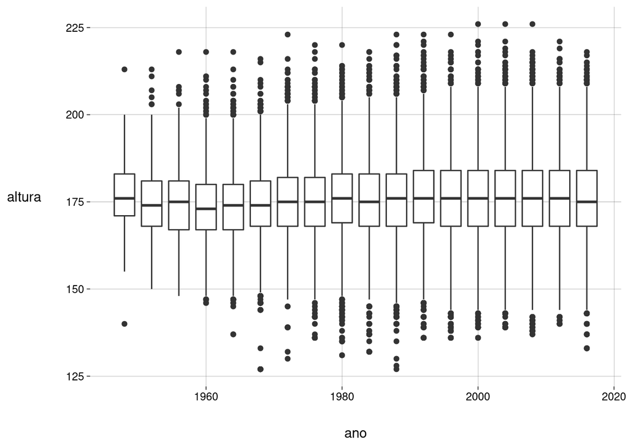

   ```r
   box_alturas <- atletas %>%
     ggplot(aes(ano, altura, group = ano)) +
       geom_boxplot()

   box_alturas
   ```

   - A mediana se manteve próxima de $175$cm ao longo dos anos.
   - A variação aumentou nos anos $60$.
2. Repita o item anterior, facetando por sexo. Use `coord_flip`. Comente os resultados.

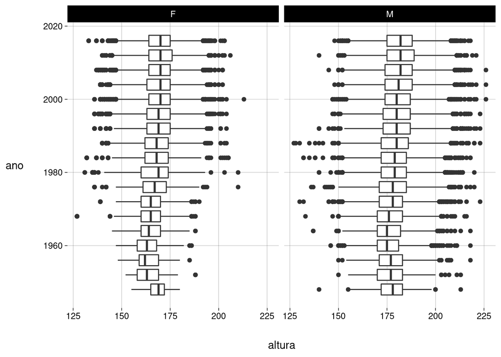

   ```r
   box_alturas +
     facet_wrap(~sexo) +
     coord_flip()
   ```

   - A mediana da altura das mulheres aumentou desde os anos $50$.
   - A mediana da altura dos homens aumentou desde os anos $60$.
   - Estas mudanças não apareciam no gráfico do item anterior porque estávamos considerando homens e mulheres em conjunto.
3. Gere dois *boxplots* lado a lado, um para os brasileiros (BRA), um para os holandeses (NED), para as alturas dos atletas. Comente o resultado.

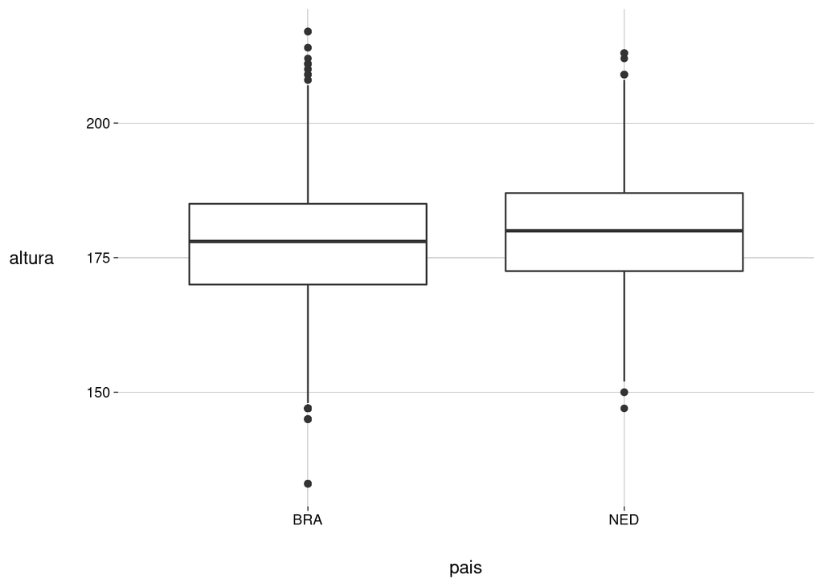

   ```r
   box_bra_ned <- atletas %>%
     filter(pais %in% c('BRA', 'NED')) %>%
     ggplot(aes(pais, altura, group = pais)) +
       geom_boxplot()

   box_bra_ned
   ```

   - A mediana e os quartis das alturas dos holandeses (considerando homens e mulheres em conjunto) são um pouco maiores do que os valores correspondentes dos brasileiros.
   - Curiosamente, existe um brasileiro mais alto do que todos os holandeses.
4. Repita o item anterior, facetando por sexo. Comente os resultados.

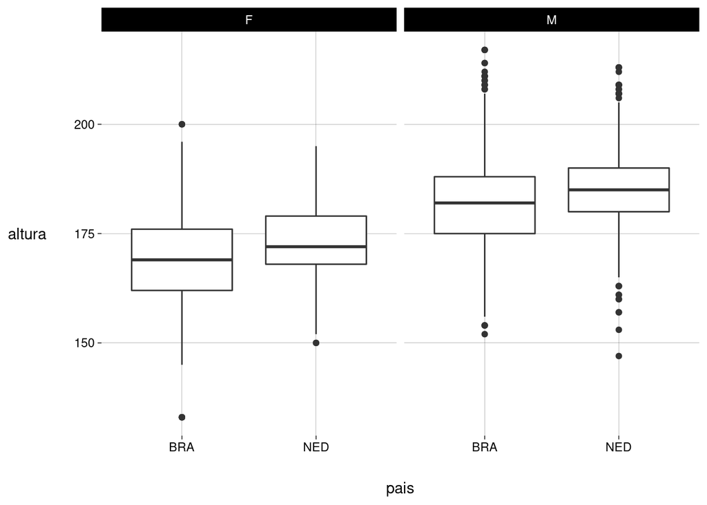

   ```r
   box_bra_ned +
     facet_wrap(~sexo)
   ```

   - Valem as mesmas observações do item anterior, quando examinamos os dados separados por sexo.
   - Existe uma mulher brasileira mais alta que todas as mulheres holandesas.

# 6 Gráficos de barras

1. Gere um gráfico de barras horizontais com as quantidades de medalhas de ouro dos $10$ países que ganharam mais medalhas de ouro nas olimpíadas de $2016$. Coloque as barras em ordem decrescente.

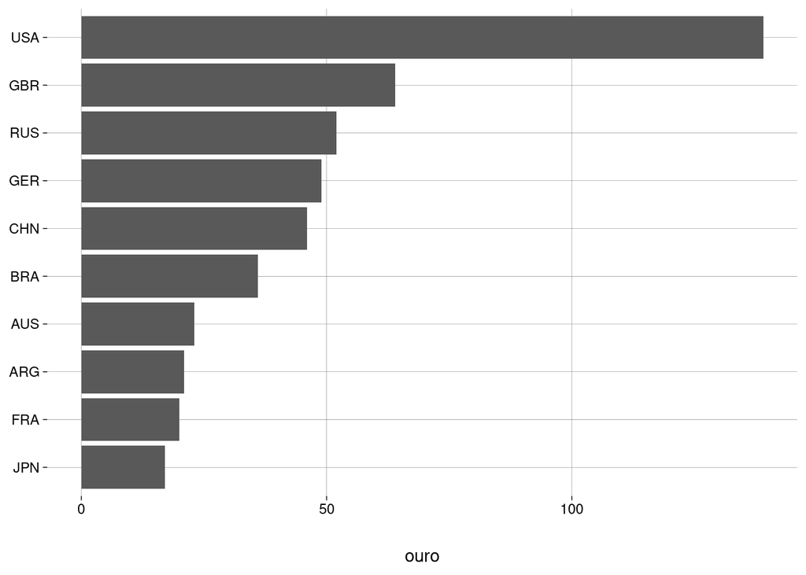

   ```r
   atletas %>%
     filter(ano == 2016 & medalha == 'Gold') %>%
     group_by(pais) %>%
     summarize(ouro = n()) %>%
     slice_max(ouro, n = 10) %>%
     ggplot(aes(fct_reorder(pais, ouro), ouro)) +
       geom_col() +
       labs(
         x = NULL
       ) +
       coord_flip()
   ```

2. Gere um gráfico de barras para as quantidades totais de medalhas do Brasil, por ano. No eixo $x$, coloque rótulos para todos os anos de Olimpíada desde $1948$. Para os rótulos ficarem legíveis, use `coord_flip`.

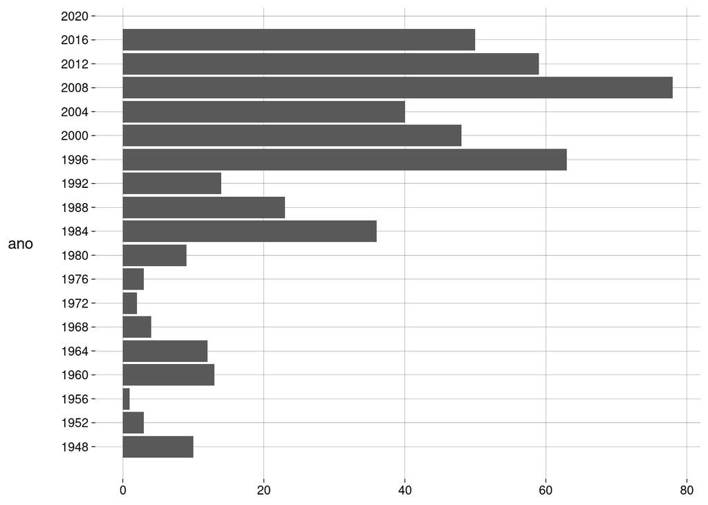

   ```r
   atletas %>%
     filter(pais == 'BRA' & !is.na(medalha)) %>%
     ggplot(aes(ano)) +
       geom_bar() +
       labs(y = NULL) +
       scale_x_continuous(breaks = seq(ano_inicial, 2020, 4)) +
       coord_flip()
   ```

3. Repita o item anterior, com duas barras lado a lado por ano, uma para cada sexo. O que você nota de estranho no resultado?

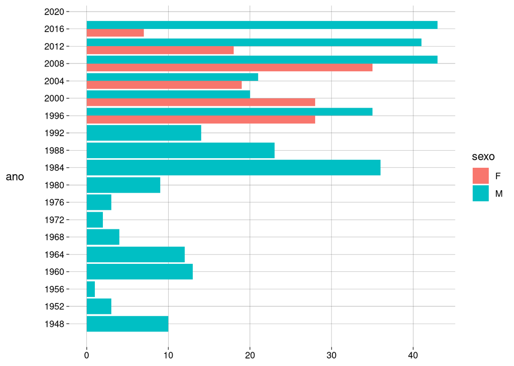

   ```r
   atletas %>%
     filter(pais == 'BRA' & !is.na(medalha)) %>%
     ggplot(aes(ano, fill = sexo)) +
       geom_bar(position = 'dodge') +
       labs(y = NULL) +
       scale_x_continuous(breaks = seq(ano_inicial, 2020, 4)) +
       coord_flip()
   ```

   A primeira vez em que uma mulher brasileira ganhou medalha foi em $1996$!

**DESAFIO:** Qual foi o primeiro ano em que cada país teve uma atleta do sexo feminino ganhando uma medalha? Construa um *data frame*. O resultado terá $98$ linhas.

```r
atletas %>%
  filter(sexo == 'F') %>%
  group_by(pais, ano) %>%
  summarize(
    medalhas = sum(!is.na(medalha)),
    acumulado = cumsum(medalhas),
    .groups = 'drop'
  ) %>%
  filter(acumulado > 0) %>%
  group_by(pais) %>%
  summarize(ano_primeira_medalha_f = min(ano)) %>%
  arrange(desc(ano_primeira_medalha_f))
```

| pais | ano_primeira_medalha_f |
| --- | --- |
| BDI | 2016 |
| CIV | 2016 |
| EGY | 2016 |
| IRI | 2016 |
| KOS | 2016 |
| PHI | 2016 |
| PUR | 2016 |
| ARM | 2012 |
| BRN | 2012 |
| MAS | 2012 |

[output cut: 88 more lines]

# 7 Gráficos de linha

1. Faça um gráfico de linha com os totais de atletas que o Brasil enviou a cada Olimpíada. Sobreponha pontos à linha. No eixo $x$, coloque rótulos para todos os anos de Olimpíada desde $1948$. Para os rótulos ficarem legíveis, gire-os em $45$ graus.

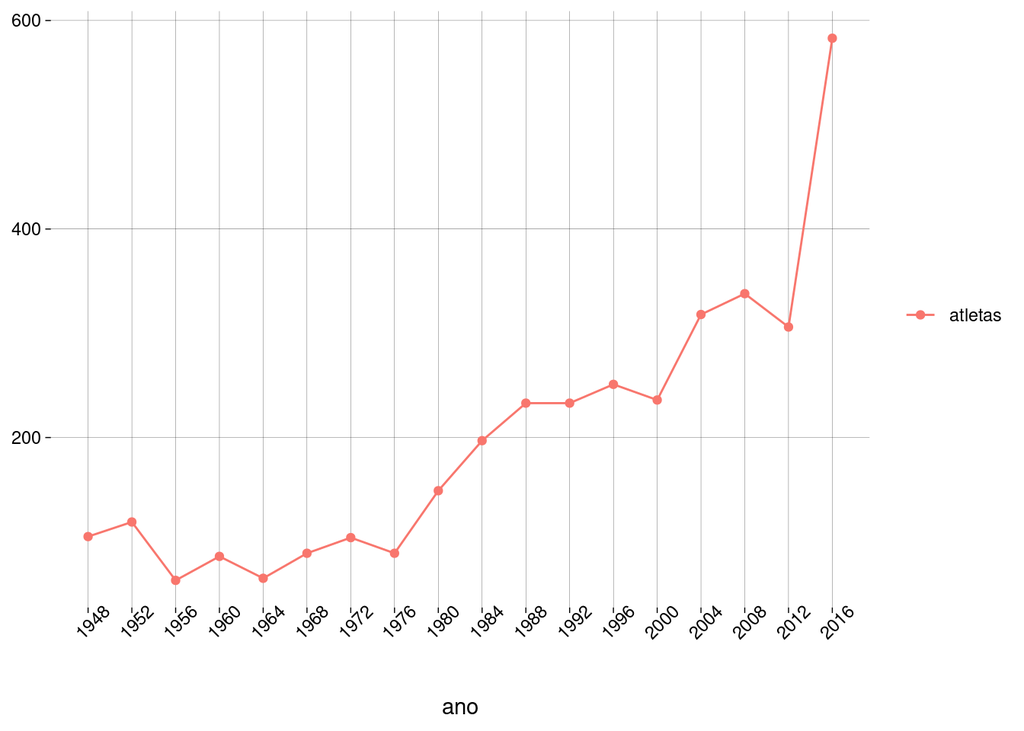

   ```r
   desempenho_brasil <- atletas %>%
     filter(pais == 'BRA') %>%
     group_by(ano) %>%
     summarize(
       n_atletas = n(),
       n_medalhas = sum(!is.na(medalha)),
       perc = n_medalhas / n_atletas
     )

   linha_atletas <- desempenho_brasil %>%
     ggplot(aes(ano)) +
       geom_line(aes(y = n_atletas, color = 'atletas')) +
       geom_point(aes(y = n_atletas, color = 'atletas')) +
       scale_x_continuous(breaks = seq(ano_inicial, 2020, 4)) +
       theme(axis.text.x = element_text(angle = 45)) +
       labs(
         color = NULL,
         y = NULL
       )

   linha_atletas
   ```

2. Acrescente ao gráfico do item anterior uma linha de outra cor, também com pontos, com as quantidades de medalhas obtidas pelo Brasil a cada ano. As cores das linhas devem aparecer na legenda, com as identificações “atletas” e “medalhas”.

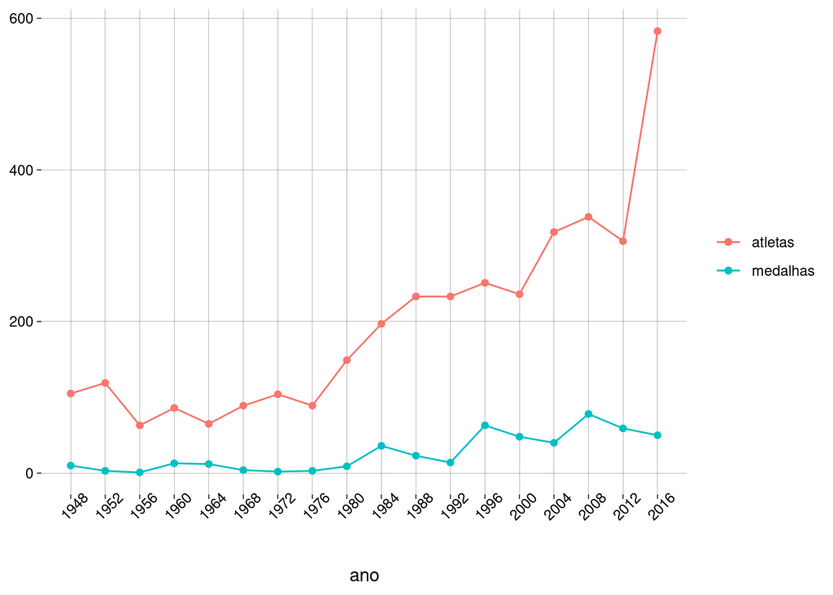

   ```r
   linha_atletas +
     geom_line(aes(y = n_medalhas, color = 'medalhas')) +
     geom_point(aes(y = n_medalhas, color = 'medalhas'))
   ```

3. Calcule, para cada ano, o percentual de medalhas ganhas em relação ao total de participações de atletas brasileiros. Gere um gráfico de linha com pontos sobrepostos. No eixo $x$, coloque rótulos para todas os anos de Olimpíada desde $1948$. Para os rótulos ficarem legíveis, gire-os em $45$ graus. Use o pacote `scales` para rotular o eixo $y$ com percentagens.

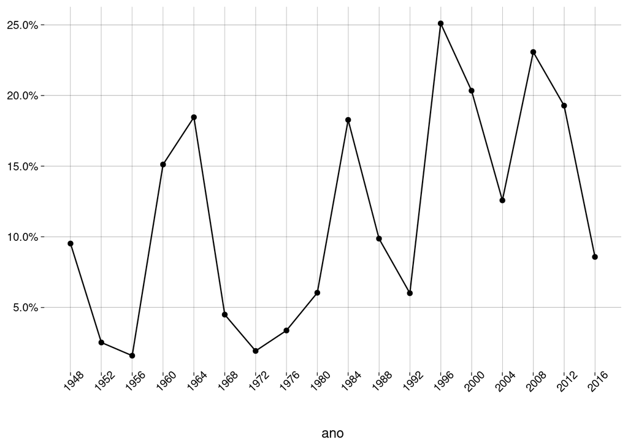

   ```r
   desempenho_brasil %>%
     ggplot(aes(ano, perc)) +
       geom_line() +
       geom_point() +
       scale_y_continuous(labels = label_percent()) +
       labs(
         y = NULL
       ) +
       scale_x_continuous(breaks = seq(ano_inicial, 2020, 4)) +
       theme(axis.text.x = element_text(angle = 45))
   ```